# 北美旅游

狗熊会

案例难度：****

案例背景：伴随互联网的普及，越来越多热爱旅游的驴友们开始选择在网上购买旅游产品，但是网上的旅游产品名目众多，面对一个相对陌生的旅行目的地，驴友们往往很难选择出最“物美价廉”的那一个、本案例通过对网上各种北美旅游产品的相关信息进行统计分析，帮助驴友们花更少的钱，购买最赞的北美旅游产品！

数据介绍：案例数据提供了2926条北美旅游数据观测，共25个变量，其中包括产品名称、旅游方式、供应商、等级、景点个数、交通情况、用餐情况、是否有自由活动、客户评分、出游人数、评价人数、报价信息、旅游线路等，详细解释请查看案例推文北美在线旅游产品选择攻略。

学习目标：

1. 了解旅游数据；

2. 对文本数据进行简单处理和描述分析。

## 任务一

读入数据，筛选出产品名称、旅游方式、供应商、等级、景点个数、交通、用餐、自由活动、总评价、出游人数、出发地、每日报价、旅游线路变量并重命名为英文变量名。

去除产品名称中带有“健康医疗”以及从国内出发（出发地为上海或北京）的样本。将数据集命名为travel_dat，查看数据的前几行。

提示：使用openxlsx包读取.xlsx数据。

```
##                                                                                                                                                             Product
## 1                                                                                           美国洛杉矶+旧金山6日5晚跟团游(3钻)·七大主题项目任选二【限时特惠】含必付
## 2                                                            美国西海岸+洛杉矶+拉斯维加斯+旧金山+黄石国家公园10日9晚跟团游(3钻)·大峡谷+羚羊彩穴+主题项目选一 含必付
## 3 美国黄石国家公园+洛杉矶+拉斯维加斯+盐湖城5日半自助游·大提顿国家公园、布莱斯国家公园·(5天)美西黄石经济游：绝美黄石公园、秀丽大提顿国家公园、布莱斯国家公园奇景不断
## 4                                                                                         美国洛杉矶+旧金山+硅谷5日4晚跟团游·17里湾优胜美地二选一【含主题乐园门票】
## 5                                                                                              美国洛杉矶+拉斯维加斯+旧金山14日13晚半自助游·1号公路+6大国家公园自驾
## 6                                                                                              美国拉斯维加斯+洛杉矶7日6晚跟团游(3钻)·七大主题公园任选三+携程大礼包
##   TravelMethod                   Agency         Star
## 1       跟团游         供应商：熊大国旅       5晚3钻
## 2       跟团游         供应商：熊大国旅       9晚3钻
## 3     半自助游 供应商：途风（熊大旗下） 暂无酒店信息
## 4       跟团游 供应商：Namei Group Inc.       4晚3钻
## 5     半自助游         供应商：熊大国旅 暂无酒店信息
## 6       跟团游         供应商：熊大国旅       6晚3钻
##                            Place        Traffic         Meal
```

[output cut: 20 more lines]

## 任务二

提取周一到周日报价中的数值部分，计算一周报价的均值（若一周7天均无报价则缺失），并以新变量“Price”存入数据集travel_dat中，剔除平均价格缺失的样本。绘制价格的对数分布直方图并进行简要解读。

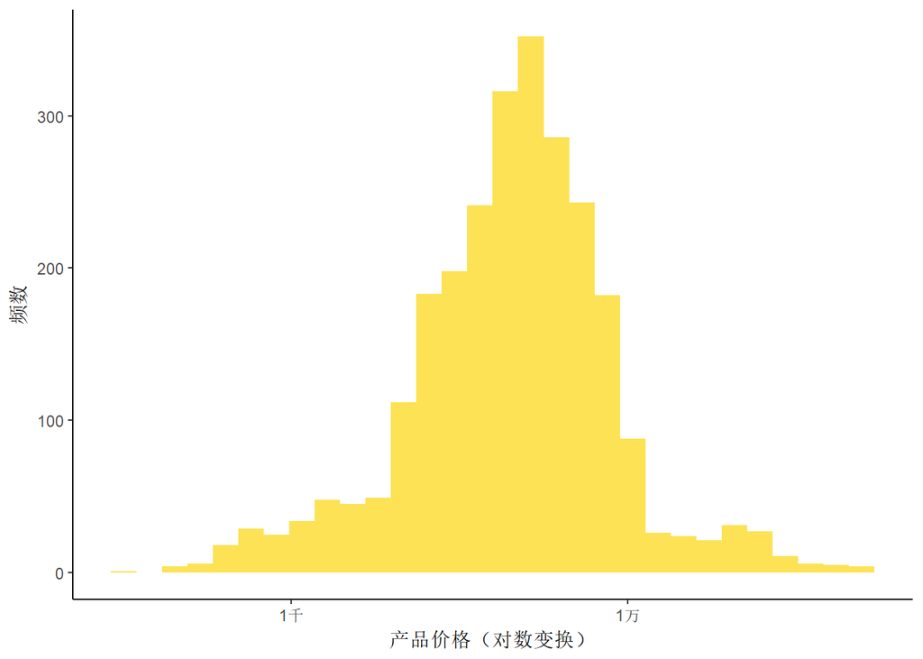

## 任务三

从“Place”变量中提取出全部景点数和经典景点数，并分别以“AllPlace”和“ClassicPlace”变量存入数据集travel_dat，变量类型为数值型。

将全部景点数按由少到多分成4组，分别为“9个及以下”，“10-16个”，“17-25个”，“25个以上”，以变量“AllPlacesGroup”变量保存在数据集travel_dat中，计算每一组内产品的平均价格并使用dplyr包的summarise()函数进行展示。

```
## # A tibble: 5 x 2
##   AllPlacesGroup `mean(Price, na.rm = T)`
##           <fctr>                    <dbl>
## 1          (0,9]                 4203.235
## 2         (9,16]                 5299.523
## 3        (16,25]                 6564.111
## 4        (25,77]                 6981.004
## 5           <NA>                 4596.389
```

## 任务四

利用周一到周日是否有报价计算每周出团日期，若当天有报价则视为出团，无报价则为未出团。提取出“仅工作日”，“仅周末”，“工作日和周末”三类出团情况并以“Date”变量存入数据集travel_dat（不属于上述任何一种情况的以缺失值存储），计算每一类出团日期的平均价格并展示。

```
## # A tibble: 3 x 2
##           Date     mean
##          <chr>    <dbl>
## 1 工作日和周末 5787.280
## 2     仅工作日 5275.202
## 3       仅周末 6929.399
```

## 任务五

提取“Star”变量中的“*钻”字符来表示产品等级，当一个产品包含多个钻级时取最大钻级，并将产品钻级以新变量“Star2”存入数据集travel_dat中，变量类型为因子型。

绘制价格的对数对产品等级的分组箱线图，并按每一等级的平均价格由低到高进行排列，对箱线图结果作出简要解读。

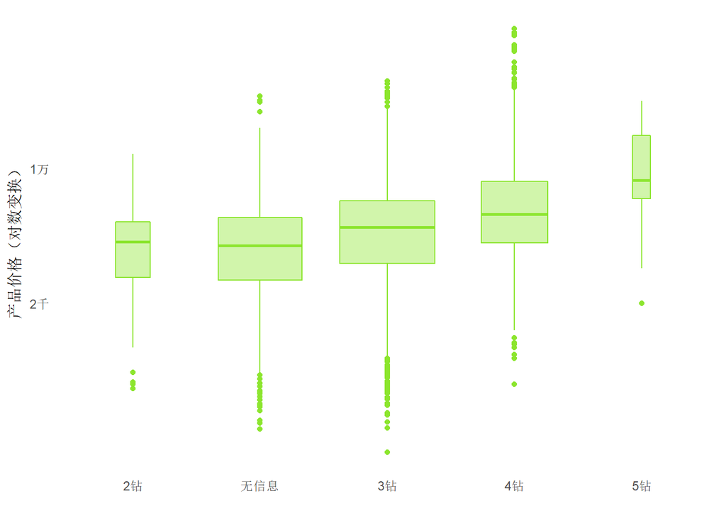